# Chapter 4

# Measures of Central Tendency

## Measures of Central Tendency

Descriptive statistics that offer information on where the scores in a data set tend to cluster.

Examples: Mean, Median, Mode.

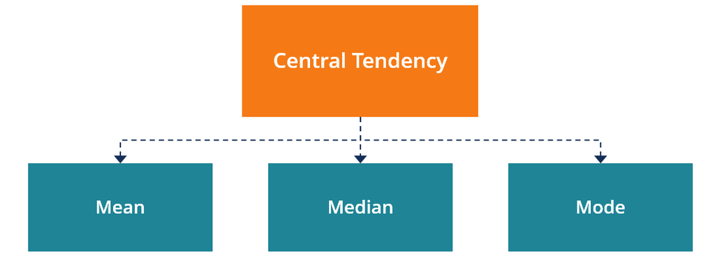

image: Corporate Finance Institute

## The Mean

The arithmetic average of a variable within a set of data.

$$\bar{x} = \frac{\sum x}{n}$$

$\bar{x}$ = Mean

$\sum$ = Summation

$x$ = Values in a column

$n$ = Sample size

## A Mean Example

We have five college student’s test scores on a particular exam:

```
          grades
student_1     85
student_2     90
student_3     75
student_4     86
student_5     91
```

$$\bar{x} = \frac{(85 + 90 + 75 + 86 +91)}{5}$$

$$\bar{x} = ?$$

## The Median

A score that cuts a distribution in half, or more simply, the true middle number.

Steps to Find the Median

[figure not shown]

## Odd Number (Method One)

We only need one step for this!

$$Median = \frac {n + 1}{2}$$

$n$ = Sample size

## Even Number (Method Two)

LM and UM are numbers within the column.

Step 1

$$Lower Middle (LM) = \frac {n}{2}$$

Step 2

$$Upper Middle (UM) = \frac {n}{2} +1$$

Step 3

$$Median = \frac {LM + UM}{2}$$

## Method One Example

```
          grades
student_1     85
student_2     90
student_3     75
student_4     86
student_5     62
student_6     79
student_7     96
```

$$Median = \frac {? + 1}{2}$$

## Method Two Example

We have four college student’s test scores on a particular exam:

```
          grades
student_1     85
student_2     90
student_3     75
student_4     86
```

$$(LM) = \frac {?}{2}$$
$$(UM) = \frac {?}{2} +1$$
$$Median = \frac {(? + ?)}{2}$$

## The Mode

The most frequent number in a set of scores or column.

Simply sort your values in ascending order, then count and compare (Hint: Look for numbers that repeat).

[figure not shown]

image: wikiHow

## A Mode Example

We have seven college student’s test scores on a particular exam:

```
          grades
student_1     85
student_2     90
student_3     75
student_4     85
student_5     62
student_6     79
student_7     96
```

$$Mode = ?$$

## Normal Distribution

A set of scores that cluster in the center and tapers off to the left and right sides of the number line.

[figure not shown]

## Outliers

Extreme values that pull the distribution which leads to a positive or negative skew.

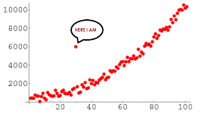

image: Medium

## Positive Skew

A clustering of scores in a distribution with some large scores pulled (or skewed) toward the positive side of the x-axis

[figure not shown]

## Negative Skew

A clustering of scores in a distribution with some small scores that pulled (or skewed)the towards the negative side of the x-axis.

[figure not shown]

## Mnemonic Devices

These are memory techniques that aid in memory retention and retrieval.

Dates back to the early Greeks.

Helps transition short term to long term memory more quickly.

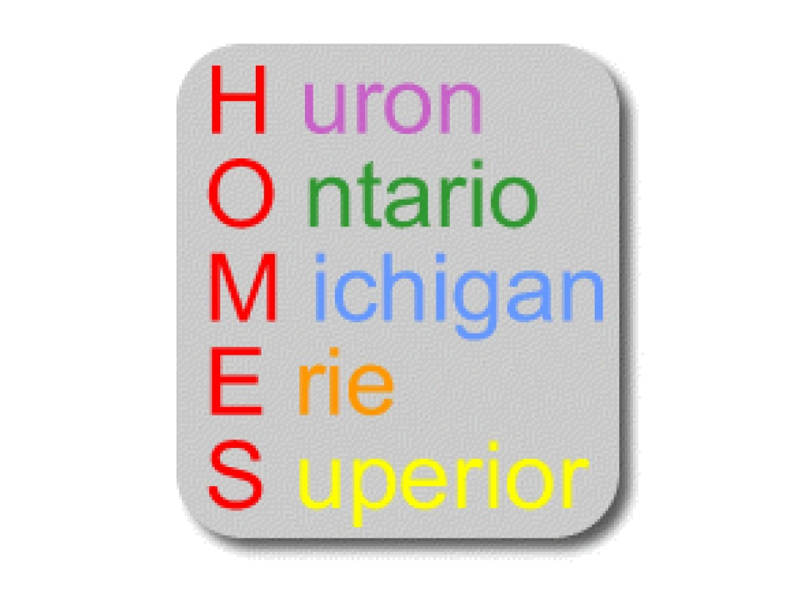

image: ShowMe

## Skew Mnemonic

When you hear the word “skew” think of laying on a beach and putting your feet together while looking at the horizon.

Your right foot is the positive skew.

Your left foot in the negative skew.

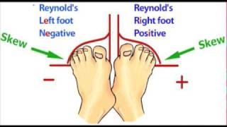

image: Michael Britt

## Pop Quiz

Using the data below, calculate the mean, median, and mode.

```
     Wins_Under_Scott_Frost
2018                      4
2019                      5
2020                      3
2021                      3
2022                      4
```

Mean = ?

Median = ?

Mode = ?

`01:00`

## Recap

- Measure of central tendency
- Outliers
- Distributions and Skews

## The Mean and Median to Determine Distribution Shape

Right skew occurs when our Mean > Median.

Left skew occurs when our Mean < Median.

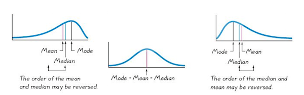

Image: Emory University

## Deviation Score

The deviation score is the distance between the mean of a variable and any given raw score in that variable.

$$d_i = x_i - \bar{x}$$

$d_i$ = deviation score

$x_i$ = a given raw score (i.e., data point)

$\bar{x}$ = the mean

## Deviation Score

This tells us two important things:

1.) How far the raw score is from the mean ($\bar{x}$)

2.) Whether the raw score is greater or less than the mean ($\bar{x}$)

Positive deviation scores represent raw scores that greater than the mean.

Negative deviation scores represent raw scores that less than the mean.

## Deviation Score Example

1.) Calculate the ($\bar{x}$)

2.) Calculate the $d_i = x_i - \bar{x}$ for each student

```
          grades
student_1     85
student_2     90
student_3     75
student_4     85
student_5     62
student_6     79
student_7     96
```

## Posit Cloud

[Head to Posit Cloud](https://posit.cloud/)

## Pop quiz

You are a researcher at a think tank and you are about to present new findings regarding the DARE program. Your data has a ($\bar{x}$) of 45, a median that is 35, what type of skew will your sample have? And what direction does it point?

A.) Positive Skew, Right  
B.) Positive Skew, Left  
C.) Negative Skew, Left  
D.) Positive Skew, Right

`01:00`

## Review

Any question about the exam?

Bring a calculator.

## Good Luck Studying

[figure not shown]

Giphy